# xwMOOC 자동차

NHTSA - 현대기아차 리콜과 불만 추세(2001-2017)

xwMOOC

2017-12-25

## 1. NHTSA API 데이터

[미국 도로교통안전국(NHTSA)](https://www.nhtsa.gov/)은 미국에서 시판되는 자동차에 대한 리콜 및 고객불만 데이터를 [NHTSA Office of Defects Investigation (ODI) - Recalls](https://one.nhtsa.gov/webapi/Default.aspx?Recalls/API/83) 웹API를 통해서 제공하고 있다.

R 팩키지도 공개되어 있어 openNHTSA를 통해서 별도 RESTful API 프로그래밍을 생략하고 R 코드로 자동차 리콜과 고객불만 데이터를 긁어올 수 있다.

## 2. 현대기아차 자동차 리콜

### 2.1. 리콜데이터 추출 환경설정

openNHTSA 예제 코드를 참조하여 2001-2017년까지 현대차와 기아차에 대한 리콜과 불만 데이터을 위한 설정을 준비한다. 더불어 현대차와 기아차를 특정짓는 색상도 설정한다.

```r
# 0. 환경설정 ----------------
# library(openNHTSA) # devtools::install_github("statwonk/openNHTSA")
# library(tidyverse)
# library(stringr)
# library(forcats)
# library(ggpubr)
# library(extrafont)
# loadfonts()

## 1.0. NHTSA 데이터 긁어오기
crawl_nhtsa <- function(maker, recall_complaint) {

  nhtsa_df <- data.frame()

  for(myear in 2001:2017) {
    tmp_df <- facility(recall_complaint) %>%
      model_year(myear) %>%
      vehicle_make(maker) %>%
      nhtsa_fetch()
    nhtsa_df <- bind_rows(nhtsa_df, tmp_df)
  }
  return(nhtsa_df)
}
## 1.0. 현대기아자동차 색상
hkmc_cols <- c(KIA = "#ff0000",
               HYUNDAI = "#0000ff")
```

### 2.2. 자동차 리콜 추세 시각화

`crawl_nhtsa` 함수에 현대차(`hyundai`)와 기아차(`kia`) 그리고 리콜인수(`recalls`)를 넣어 데이터를 긁어오고 이를 바탕으로 연도별 현대기아차 리콜 횟수를 시각화한다.

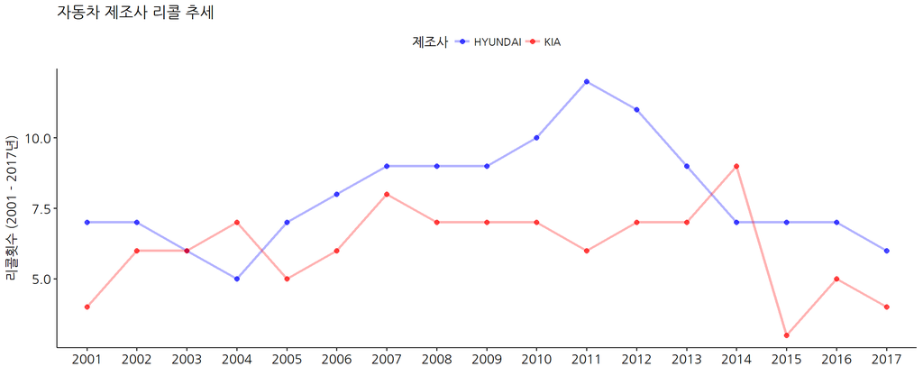

```r
# 1. 리콜 데이터 가져오기 ----------------
## 1.1. 현대차
hyundai_df <- crawl_nhtsa("hyundai", "recalls")

## 1.2. 기아차
kia_df <- crawl_nhtsa("kia", "recalls")

## 1.3. 데이터 병합
recall_df <- bind_rows(hyundai_df, kia_df)

## 1.5. 데이터 시각화 -------------
recall_df %>%
  count(Make, ModelYear) %>%
  ggplot(aes(x=ModelYear, y=n, group=Make, color=Make)) +
    geom_line(size=1.1, alpha=0.3) +
    geom_point(size=2, alpha=0.7) +
    theme_pubr(base_family = "NanumGothic") +
    labs(x="", y="리콜횟수 (2001 - 2017년)", title="자동차 제조사 리콜 추세", color="제조사") +
    scale_color_manual(values=hkmc_cols)
```

## 3. 현대기아자동차 불만 추세

`crawl_nhtsa` 함수에 현대차(`hyundai`)와 기아차(`kia`) 그리고 불만(`complaints`)인수를 넣어 데이터를 긁어오고 이를 바탕으로 연도별 현대기아차 불만 횟수를 시각화한다.

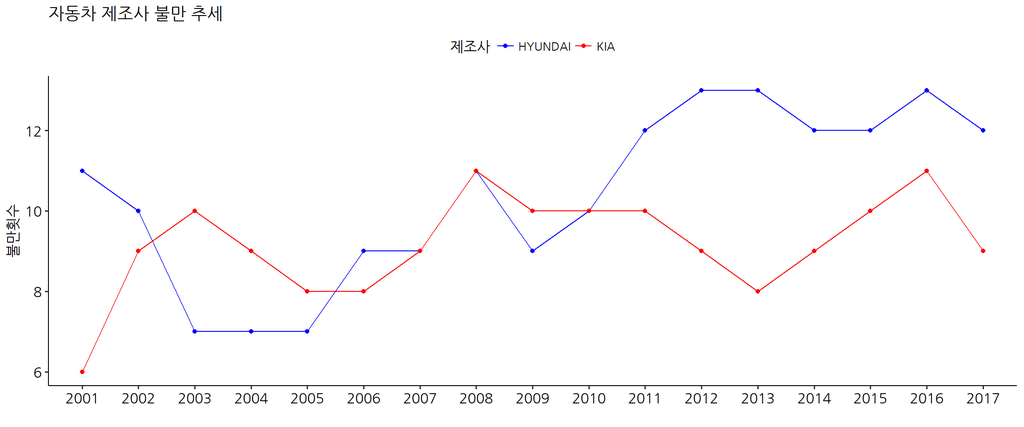

```r
# 2. 항의 데이터 가져오기 ----------------
## 2.1. 현대차
hyundai_comp_df <- crawl_nhtsa("hyundai", "complaints")

## 2.2. 기아차
kia_comp_df <- crawl_nhtsa("kia", "complaints")

## 2.3. 데이터 병합
complaint_df <- bind_rows(hyundai_comp_df, kia_comp_df)

# 3. 데이터 시각화 -------------
## 3.1. 제조사별 연도 추세
complaint_df %>%
  count(Make, ModelYear) %>%
  ggplot(aes(x=ModelYear, y=n, group=Make, color=Make)) +
  geom_line() +
  geom_point() +
  theme_pubr(base_family = "NanumGothic") +
  labs(x="", y="불만횟수", title="자동차 제조사 불만 추세", color="제조사") +
  scale_color_manual(values=hkmc_cols)
```

## 3. 현대기아자동차 모델별 리콜과 불만 횟수

2001 - 2017년 현대기아자동차 모델별 리콜과 불만 횟수를 세어보자.

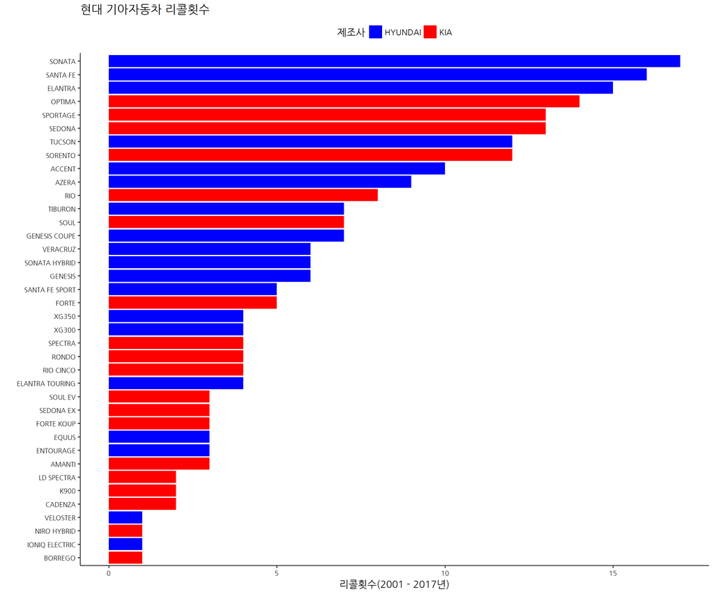

```r
# 3. 모델별 데이터 시각화 -------------
## 3.1. 모델별 리콜 데이터 시각화
recall_df %>%
  filter(str_detect(Make, "HYUNDAI|KIA")) %>%
  count(Make, Model) %>%
  ggplot(aes(x=reorder(Model, n), y=n, fill=Make)) +
  geom_bar(stat="identity") +
  coord_flip() +
  labs(x="", y="리콜횟수(2001 - 2017년)", title="현대 기아자동차 리콜횟수", fill="제조사") +
  theme_pubr(base_family = "NanumGothic") +
  scale_fill_manual(values=hkmc_cols) +
  theme(axis.text = element_text(size=8))
```

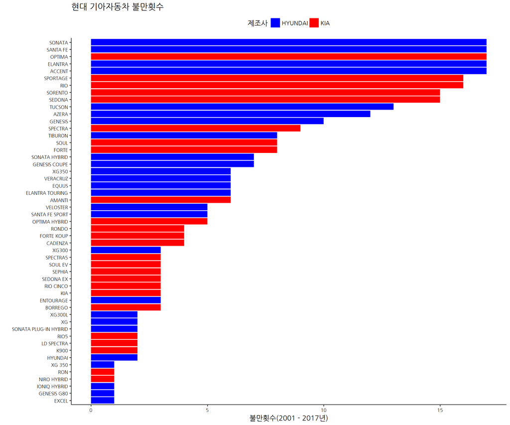

```r
## 3.2. 모델별 불만 데이터 시각화
complaint_df %>%
  filter(str_detect(Make, "HYUNDAI|KIA")) %>%
  count(Make, Model) %>%
  ggplot(aes(x=reorder(Model, n), y=n, fill=Make)) +
  geom_bar(stat="identity") +
  coord_flip() +
  labs(x="", y="불만횟수(2001 - 2017년)", title="현대 기아자동차 불만횟수", fill="제조사") +
  theme_pubr(base_family = "NanumGothic") +
  scale_fill_manual(values=hkmc_cols) +
  theme(axis.text = element_text(size=8))
```